# Explore the NOAA Storm Database for Severe Weather Events

Sohail Munir Khan

20 July 2015

## Synopsis

Storms and other severe weather events can cause both public health and economic problems for communities and municipalities. Many severe events can result in fatalities, injuries, and property damage, and preventing such outcomes to the extent possible is a key concern.

This project involves exploring the U.S. National Oceanic and Atmospheric Administration’s (NOAA) storm database. This database tracks characteristics of major storms and weather events in the United States, including when and where they occur, as well as estimates of any fatalities, injuries, and property damage.

The data for this project is downloaded from web location: [Storm Data](https://d396qusza40orc.cloudfront.net/repdata%2Fdata%2FStormData.csv.bz2)

The events in the database start in the year 1950 and end in November 2011.

## Data Processing

read.csv can process bz2 compressed file. Warning: It takes quite a bit of time to process and retrieve `raw_stormdata`  
PROPDMGEXP and CROPDMGEXP are measurements scaling values. Some of them are incorrect like ‘-’, ‘?’ and ‘+’ which have been calculated as Zero values. Other values have been translated by using these variables’ transaltion (see exp_map_func function) and PROPDMG, CROPDMG values to get PROPVAL and CROPVAL respectively

```r
stormDataZipfile <- "repdata-data-StormData.csv.bz2"
raw_stormdata <- read.csv(stormDataZipfile)

# Showing the Dimension for our raw Storm Data
dim(raw_stormdata)
```

```
## [1] 902297     37
```

```r
# Showing important variables that we will use for our analysis
head(raw_stormdata[,c("EVTYPE","FATALITIES","INJURIES","PROPDMG","PROPDMGEXP","CROPDMG","CROPDMGEXP")])
```

```
##    EVTYPE FATALITIES INJURIES PROPDMG PROPDMGEXP CROPDMG CROPDMGEXP
## 1 TORNADO          0       15    25.0          K       0
## 2 TORNADO          0        0     2.5          K       0
## 3 TORNADO          0        2    25.0          K       0
## 4 TORNADO          0        2     2.5          K       0
## 5 TORNADO          0        2     2.5          K       0
## 6 TORNADO          0        6     2.5          K       0
```

```r
# Showing the unique values from xxDMGEXP variables for both PROP and CROP that we have to convert
unique(raw_stormdata$CROPDMGEXP)
```

```
## [1]   M K m B ? 0 k 2
## Levels:  ? 0 2 B k K m M
```

```r
unique(raw_stormdata$PROPDMGEXP)
```

```
##  [1] K M   B m + 0 5 6 ? 4 2 3 h 7 H - 1 8
## Levels:  - ? + 0 1 2 3 4 5 6 7 8 B h H K m M
```

```r
# Map from xxDMGEXP value to its correct multiplier to be multiplied with xxDMG to get xxVAL
exp_map_func <- function(expr) {
  ifelse(expr=='', 1,
  ifelse(expr=='0', 1e0,
  ifelse(expr=='1', 1e1,
  ifelse(expr=='2', 1e2,
  ifelse(expr=='3', 1e3,
  ifelse(expr=='4', 1e4,
  ifelse(expr=='5', 1e5,
  ifelse(expr=='6', 1e6,
  ifelse(expr=='7', 1e7,
  ifelse(expr=='8', 1e8,
  ifelse(expr=='b' | expr=='B', 1e9,
  ifelse(expr=='h' | expr=='H', 1e2,
  ifelse(expr=='k' | expr=='K', 1e3,
  ifelse(expr=='m' | expr=='M', 1e6,
         0 )))))))))))))) # '-', '?', '+' as well anything else will be translated to a 0 xxVAL
}

# Calculate the xxVAL columns by converting xxDMGEXP values and multiplying it with xxPROPDMG or xxCROPDMP variables
raw_stormdata$PROPVAL <- raw_stormdata$PROPDMG * exp_map_func(raw_stormdata$PROPDMGEXP)
raw_stormdata$CROPVAL <- raw_stormdata$CROPDMG * exp_map_func(raw_stormdata$CROPDMGEXP)

# Install "dplyr" package if required.
dplyrPackage <- "dplyr"
if (!dplyrPackage %in% installed.packages()[,"Package"])
    install.packages(dplyrPackage,
                     repos="http://cran.rstudio.com/")

# Load "dplyr" package needed to group data to summarize
library(dplyr, warn.conflicts = FALSE)

# Retrieved the variables that contain the information about Health(FATALITIES, INJURIES) and Ecomonic(PROPDMG, CROPDMG) Impact along with our EVTYPE variable
imptdf <- tbl_df(raw_stormdata[,c("EVTYPE","FATALITIES","INJURIES","PROPVAL","PROPDMG","PROPDMGEXP","CROPVAL","CROPDMG","CROPDMGEXP")])
# Showing some values that confirm that xxVAL variables are correctly calculated
imptdf[imptdf$CROPDMG!=0,]
```

```
## Source: local data frame [22,099 x 9]
##
##                       EVTYPE FATALITIES INJURIES PROPVAL PROPDMG
## 1  HURRICANE OPAL/HIGH WINDS          2        0 1.0e+08     0.1
## 2         THUNDERSTORM WINDS          0        0 5.0e+06     5.0
## 3             HURRICANE ERIN          0        0 2.5e+07    25.0
## 4             HURRICANE OPAL          0        0 4.8e+07    48.0
## 5             HURRICANE OPAL          0        0 2.0e+07    20.0
## 6         THUNDERSTORM WINDS          0        0 5.0e+04    50.0
## 7         THUNDERSTORM WINDS          0        2 5.0e+05   500.0
## 8                    TORNADO          0        5 5.0e+05   500.0
## 9                    TORNADO          0        0 5.0e+05   500.0
## 10   THUNDERSTORM WINDS/HAIL          0        0 5.0e+03     5.0
## ..                       ...        ...      ...     ...     ...
## Variables not shown: PROPDMGEXP (fctr), CROPVAL (dbl), CROPDMG (dbl),
##   CROPDMGEXP (fctr)
```

```r
# Select only the variables that are needed
valuetdf <- imptdf %>% select(EVTYPE, FATALITIES, INJURIES, PROPVAL, CROPVAL)
```

## Results

All grouping of data is based off of ‘EVTYPE’ variable  
Each of the FATALITIES, INJURIES, PROPVAL, CROPVAL have been individually summarised and top 10 results are shown  
To answer our main question for Health (or most harmful), I have calculated a new summarised table that gets its stats from a new variable **10 * FATALITIES + INJURIES**. The reason has been discussed below but the top 10 of these will be used to answer our main analysis question about most harmful to population health  
To answer our main question for Economic affects, I have calculated a new summarised table that gets its stats from a new variable **PROPVAL + CROPVAL**. The top 10 of these will be used to answer our main analysis question about economic consequences

```r
# Install "ggplot2" package if required.
ggplot2Package <- "ggplot2"
if (!ggplot2Package %in% installed.packages()[,"Package"])
    install.packages(ggplot2Package,
                     repos="http://cran.rstudio.com/")

# Load "ggplot2" package needed to group data to summarize
library(ggplot2, warn.conflicts = FALSE)

# Group by our most important EVTYPE variable
groupedtdf <- valuetdf %>% group_by(EVTYPE)

# Showing the top 10 Fatalities by using groupedtdf and summarise to calculate top values
fatalitiestdf <- groupedtdf %>% summarise(sumFatalities = sum(FATALITIES)) %>% arrange(desc(sumFatalities))
fatalitiestdf[1:10,]
```

```
## Source: local data frame [10 x 2]
##
##            EVTYPE sumFatalities
## 1         TORNADO          5633
## 2  EXCESSIVE HEAT          1903
## 3     FLASH FLOOD           978
## 4            HEAT           937
## 5       LIGHTNING           816
## 6       TSTM WIND           504
## 7           FLOOD           470
## 8     RIP CURRENT           368
## 9       HIGH WIND           248
## 10      AVALANCHE           224
```

```r
# Showing the top 10 Injuries by using groupedtdf and summarise to calculate top values
injuriestdf <- groupedtdf %>% summarise(sumInjuries = sum(INJURIES)) %>% arrange(desc(sumInjuries))
injuriestdf[1:10,]
```

```
## Source: local data frame [10 x 2]
##
##               EVTYPE sumInjuries
## 1            TORNADO       91346
## 2          TSTM WIND        6957
## 3              FLOOD        6789
## 4     EXCESSIVE HEAT        6525
## 5          LIGHTNING        5230
## 6               HEAT        2100
## 7          ICE STORM        1975
## 8        FLASH FLOOD        1777
## 9  THUNDERSTORM WIND        1488
## 10              HAIL        1361
```

```r
# Creating a new temp healthtdf variable with the value (10 * FATALITIES + INJURIES) meaning we value FATALITIES as 10 times worse than INJURIES. Then showing the top 10 healthtdf indicators
healthtdf <- groupedtdf %>% summarise(sumHealths = sum(10 * FATALITIES + INJURIES)) %>% arrange(desc(sumHealths))
top_healthindicators <- healthtdf[1:10,]
top_healthindicators
```

```
## Source: local data frame [10 x 2]
##
##            EVTYPE sumHealths
## 1         TORNADO     147676
## 2  EXCESSIVE HEAT      25555
## 3       LIGHTNING      13390
## 4       TSTM WIND      11997
## 5     FLASH FLOOD      11557
## 6           FLOOD      11489
## 7            HEAT      11470
## 8     RIP CURRENT       3912
## 9       HIGH WIND       3617
## 10   WINTER STORM       3381
```

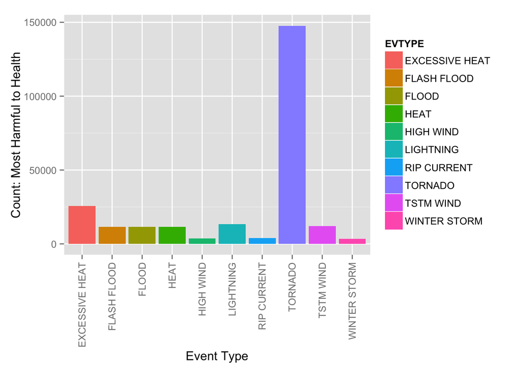

```r
# Plot top_healthindicators
ggplot(data=top_healthindicators, aes(x=EVTYPE, y=sumHealths, fill=EVTYPE)) + geom_bar(stat="identity") + xlab("Event Type") + ylab("Count: Most Harmful to Health") + theme(axis.text.x=element_text(angle=90,hjust=1,vjust=0.5))
```

Questions:

- Across the United States, which types of events (as indicated in the EVTYPE variable) are most harmful with respect to population health?  
TORNADO, EXCESSIVE HEAT, LIGHTNING are the top 3 reasons. Others are shown in the plot above

```r
# Showing the top 10 Injuries by using groupedtdf and summarise to calculate top values
propvalstdf <- groupedtdf %>% summarise(sumPropvals = sum(PROPVAL)) %>% arrange(desc(sumPropvals))
propvalstdf[1:10,]
```

```
## Source: local data frame [10 x 2]
##
##               EVTYPE  sumPropvals
## 1              FLOOD 144657709807
## 2  HURRICANE/TYPHOON  69305840000
## 3            TORNADO  56947380616
## 4        STORM SURGE  43323536000
## 5        FLASH FLOOD  16822673978
## 6               HAIL  15735267513
## 7          HURRICANE  11868319010
## 8     TROPICAL STORM   7703890550
## 9       WINTER STORM   6688497251
## 10         HIGH WIND   5270046260
```

```r
# Showing the top 10 Injuries by using groupedtdf and summarise to calculate top values
cropvalstdf <- groupedtdf %>% summarise(sumCropvals = sum(CROPVAL)) %>% arrange(desc(sumCropvals))
cropvalstdf[1:10,]
```

```
## Source: local data frame [10 x 2]
##
##               EVTYPE sumCropvals
## 1            DROUGHT 13972566000
## 2              FLOOD  5661968450
## 3        RIVER FLOOD  5029459000
## 4          ICE STORM  5022113500
## 5               HAIL  3025954473
## 6          HURRICANE  2741910000
## 7  HURRICANE/TYPHOON  2607872800
## 8        FLASH FLOOD  1421317100
## 9       EXTREME COLD  1292973000
## 10      FROST/FREEZE  1094086000
```

```r
# Creating a new temp economictdf variable with the value (PROPVAL + CROPVAL). Then showing the top 10 economictdf indicators by using groupedtdf and summarise to calculate top values
economictdf <- groupedtdf %>% summarise(sumVals = sum(PROPVAL + CROPVAL)) %>% arrange(desc(sumVals))
top_economicindicators <- economictdf[1:10,]
top_economicindicators
```

```
## Source: local data frame [10 x 2]
##
##               EVTYPE      sumVals
## 1              FLOOD 150319678257
## 2  HURRICANE/TYPHOON  71913712800
## 3            TORNADO  57362333886
## 4        STORM SURGE  43323541000
## 5               HAIL  18761221986
## 6        FLASH FLOOD  18243991078
## 7            DROUGHT  15018672000
## 8          HURRICANE  14610229010
## 9        RIVER FLOOD  10148404500
## 10         ICE STORM   8967041360
```

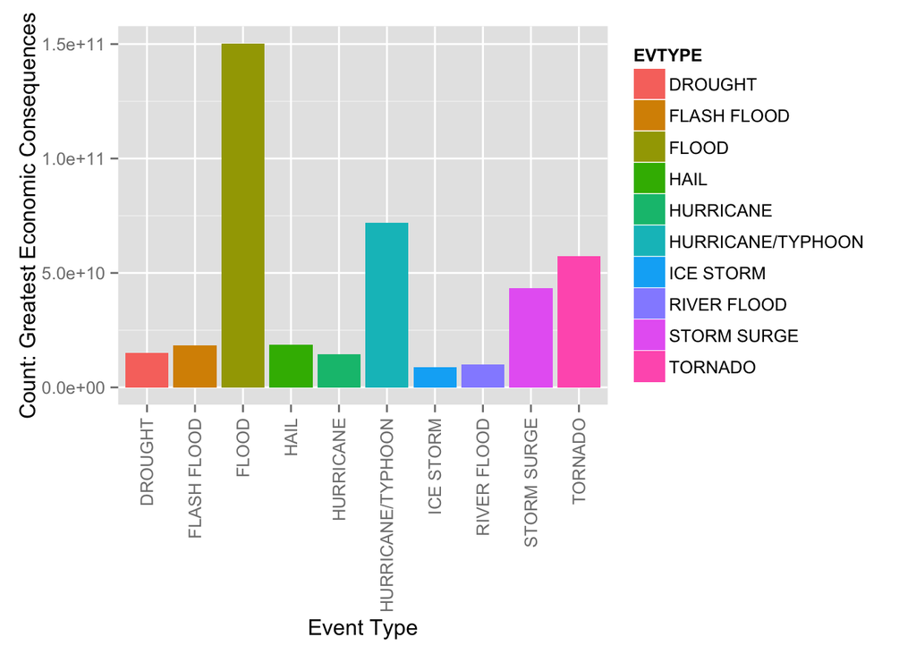

```r
# Plot top_economicindicators
ggplot(data=top_economicindicators, aes(x=EVTYPE, y=sumVals, fill=EVTYPE)) + geom_bar(stat="identity") + xlab("Event Type") + ylab("Count: Greatest Economic Consequences") + theme(axis.text.x=element_text(angle=90,hjust=1,vjust=0.5))
```

Question:

- Across the United States, which types of events have the greatest economic consequences?  
FLOOD, HURRICANE/TYPHOON, TORNADO are the top 3 reasons. Others are shown in the plot above